# Google Data Analytics Capstone Study

2022-07-20

# Data Analytics Case Study

## How can a Wellness Technology Company Play it Smart?

### Scenario

I am a junior data analyst working on the marketing analyst team at Bellabeat, a high-tech manufacturer of health-focused products for women. Bellabeat is a successful small company, but they have the potential to become a larger player in the global smart device market. Urška Sršen, co-founder and Chief Creative Officer of Bellabeat, believes that analysing smart device fitness data could help unlock new growth opportunities for the company. I have been asked to focus on one of Bellabeat’s products and analyse smart device data to gain insight into how consumers are using their smart devices. The insights that I discover will then help guide marketing strategy for the company. I will present my analysis to the Bellabeat executive team along with my high-level recommendations for Bellabeat’s marketing strategy.

### Bellabeat Products

Bellabeat App: The Bellabeat app provides users with health data related to their activity, sleep, stress, menstrual cycle, and mindfulness habits. This data can help users better understand their current habits and make healthy decisions. The Bellabeat app connects to their line of smart wellness products.

Leaf: : Bellabeat’s classic wellness tracker can be worn as a bracelet, necklace, or clip. The Leaf tracker connects to the Bellabeat app to track activity, sleep, and stress.

Time: : This wellness watch combines the timeless look of a classic timepiece with smart technology to track user activity, sleep, and stress. The Time watch connects to the Bellabeat app to provide you with insights into your daily wellness.

Spring: This is a water bottle that tracks daily water intake using smart technology to ensure that you are appropriately hydrated throughout the day. The Spring bottle connects to the Bellabeat app to track your hydration levels.

Bellabeat Membership: Bellabeat also offers a subscription-based membership program for users. Membership gives users 24/7 access to fully personalized guidance on nutrition, activity, sleep, health and beauty, and mindfulness based on their lifestyle and goals.

## 1. Ask

The business task is to analyse smart device usage data of non-Bellabeat smart devices to gain insight into relevant (successful and unsuccessful) consumer trends within the global smart device market, as well as to discover how to use these trends to apply to Bellabeat customers and to influence future Bellabeat marketing strategies. This is done by applying said insights to the Bellabeat App and to future products in order to maximise profits and growth for the company and to capitilse on Bellabeat’s rapidly growing consumer base in the smart device/tech-wellness space. Urška Sršen, Sando Mur (Bellabeat’s other co-founder and key member of the Bellabeat executive team), the Bellabeat executive team, the Bellabeat Marketing Analytics Team, and the Bellabeat investors are the key stakeholders that need to be considered in my data analysis and decisions.

## 2. Prepare

The Data used contains a total of 18 data sets provided by FitBit Fitness Tracker Data (CC0: Public Domain, dataset made available through Mobius). They are individually stored as csv. files but the three we will be working on is the daily activity dataset, the weight dataset and the daily sleep set. These three files contain relevant data that are also tracked by the Bellabeat products. This will provide me with the most relevant insights to complete the business task.

### Issues wit the Data Credibility

Overall, the conclusions made from this analysis should be taken seriously, as the data credibility and data foundation are lacking. However, the general insights could still prove to be useful by highlighting possible shortcomings in FitBit’s data tracking (by FitBit itself or by the individuals), which Bellabeat can then improve on through innovative features exclusive to the Bellabeat product line.

### Loading Packages

Below are the packages that will be used in this case study or will be used for any other functions:

```r
library(tidyverse)
library(lubridate)
```

```r
library(ggplot2)
library(readr)
library(tidyr)
library(dplyr)
library(skimr)
library(janitor)
library(scales)
```

### Importing Data Sets

Import these three data sets.

```r
activity_daily <-read_csv("Bellabeat/dailyActivity_merged.csv")
weight <- read_csv("Bellabeat/weightLogInfo_merged.csv")
sleep_daily <-read_csv("Bellabeat/sleepDay_merged.csv")
```

## 3. Process

Now it is time to verify and clean the data in order to prepare it for analysis.

```r
colnames(activity_daily)
```

```
##  [1] "Id"                       "ActivityDate"
##  [3] "TotalSteps"               "TotalDistance"
##  [5] "TrackerDistance"          "LoggedActivitiesDistance"
##  [7] "VeryActiveDistance"       "ModeratelyActiveDistance"
##  [9] "LightActiveDistance"      "SedentaryActiveDistance"
## [11] "VeryActiveMinutes"        "FairlyActiveMinutes"
## [13] "LightlyActiveMinutes"     "SedentaryMinutes"
## [15] "Calories"
```

```r
colnames(weight)
```

```
## [1] "Id"             "Date"           "WeightKg"       "WeightPounds"
## [5] "Fat"            "BMI"            "IsManualReport" "LogId"
```

```r
colnames(sleep_daily)
```

```
## [1] "Id"                 "SleepDay"           "TotalSleepRecords"
## [4] "TotalMinutesAsleep" "TotalTimeInBed"
```

The first thing I noticed with this preview ist that the dataset only contains data for one month rather than two which raises the credibilty of this data. The second thing I noticed is the inconsistency of logging the user data. And several people did not participate in any activity for the whole month. This makes a the business task harder to accomplish.

```r
activity_daily_new <- activity_daily %>%
  filter(TotalSteps !=0)
view(activity_daily_new)
```

Removing the zero steps will definitely help with the analysis. However there are several occurences where the calories burned were low or the number of steps were low. I have decided to keep them in the data set because these outliers could convey that the user was ill or was resting for a day.

For the weight and sleep data sets, I found that it would be best to separate the datatime column into two columns for Date and Time. There is also an inconsistency in the unique Id’s present in each data set.

```r
weight_new <- weight %>%
  separate(Date, c("Date", "Time"), " ")
sleep_daily_new <- sleep_daily %>%
  separate(SleepDay, c("Date", "Time"), " ")
n_distinct(activity_daily_new$Id)
```

```
## [1] 33
```

```r
n_distinct(weight_new$Id)
```

```
## [1] 8
```

```r
n_distinct(sleep_daily_new$Id)
```

```
## [1] 24
```

```r
nrow(activity_daily_new)
```

```
## [1] 863
```

```r
nrow(weight_new)
```

```
## [1] 67
```

```r
nrow(sleep_daily_new)
```

```
## [1] 413
```

```r
nrow(unique(activity_daily_new))
```

```
## [1] 863
```

```r
nrow(unique(weight_new))
```

```
## [1] 67
```

```r
nrow(unique(sleep_daily_new))
```

```
## [1] 410
```

Interestingly, not everyone involved in this survey provided tracking data for each data set. Only eight people entered their weight (where only two people logged/tracked most of the data), and only 24 people entered their sleep data. Also, there are 33 people recorded in the daily activity data, despite the data citation saying there are 30 people in the sample size. This further questions the credibility of the data as it seems to become even less comprehensive/reliable and more dirty the more I look into it. I might not be able to cross-analyse the data as much as I would like due to the number of incomplete and inconsistently tracked data. Due to the incompleteness of those data sets, I may just focus on the ‘activity_daily’ data set for a more focused analysis and then include some general recommendations for improvement on data logging/tracking consistencies for recording weight and sleep.

The fourth thing I noticed is that there could be some duplicated rows in some of the data sets. I will confirm this and delete the duplicated rows for cleaner data.

```r
sleep_daily_new_v2 <-unique(sleep_daily_new)
```

Its always apart of the process to check for duplicate data

## 4.Analyse

Now the data is clean and is ready to be analyzed. In this step, I will identify trends and relationships. First lets obtain summaries for each data set.

```r
skim_without_charts(activity_daily_new)
```

Data summary

| Name | activity_daily_new |
| --- | --- |
| Number of rows | 863 |
| Number of columns | 15 |
| _______________________ |  |
| Column type frequency: |  |
| character | 1 |
| numeric | 14 |
| ________________________ |  |
| Group variables | None |

**Variable type: character**

| skim_variable | n_missing | complete_rate | min | max | empty | n_unique | whitespace |
| --- | --- | --- | --- | --- | --- | --- | --- |
| ActivityDate | 0 | 1 | 8 | 9 | 0 | 31 | 0 |

**Variable type: numeric**

| skim_variable | n_missing | complete_rate | mean | sd | p0 | p25 | p50 | p75 | p100 |
| --- | --- | --- | --- | --- | --- | --- | --- | --- | --- |
| Id | 0 | 1 | 4.857542e+09 | 2.418405e+09 | 1503960366 | 2.320127e+09 | 4.445115e+09 | 6.962181e+09 | 8.877689e+09 |
| TotalSteps | 0 | 1 | 8.319390e+03 | 4.744970e+03 | 4 | 4.923000e+03 | 8.053000e+03 | 1.109250e+04 | 3.601900e+04 |
| TotalDistance | 0 | 1 | 5.980000e+00 | 3.720000e+00 | 0 | 3.370000e+00 | 5.590000e+00 | 7.900000e+00 | 2.803000e+01 |
| TrackerDistance | 0 | 1 | 5.960000e+00 | 3.700000e+00 | 0 | 3.370000e+00 | 5.590000e+00 | 7.880000e+00 | 2.803000e+01 |
| LoggedActivitiesDistance | 0 | 1 | 1.200000e-01 | 6.500000e-01 | 0 | 0.000000e+00 | 0.000000e+00 | 0.000000e+00 | 4.940000e+00 |
| VeryActiveDistance | 0 | 1 | 1.640000e+00 | 2.740000e+00 | 0 | 0.000000e+00 | 4.100000e-01 | 2.270000e+00 | 2.192000e+01 |
| ModeratelyActiveDistance | 0 | 1 | 6.200000e-01 | 9.100000e-01 | 0 | 0.000000e+00 | 3.100000e-01 | 8.700000e-01 | 6.480000e+00 |
| LightActiveDistance | 0 | 1 | 3.640000e+00 | 1.860000e+00 | 0 | 2.340000e+00 | 3.580000e+00 | 4.890000e+00 | 1.071000e+01 |
| SedentaryActiveDistance | 0 | 1 | 0.000000e+00 | 1.000000e-02 | 0 | 0.000000e+00 | 0.000000e+00 | 0.000000e+00 | 1.100000e-01 |
| VeryActiveMinutes | 0 | 1 | 2.302000e+01 | 3.365000e+01 | 0 | 0.000000e+00 | 7.000000e+00 | 3.500000e+01 | 2.100000e+02 |
| FairlyActiveMinutes | 0 | 1 | 1.478000e+01 | 2.043000e+01 | 0 | 0.000000e+00 | 8.000000e+00 | 2.100000e+01 | 1.430000e+02 |
| LightlyActiveMinutes | 0 | 1 | 2.100200e+02 | 9.678000e+01 | 0 | 1.465000e+02 | 2.080000e+02 | 2.720000e+02 | 5.180000e+02 |
| SedentaryMinutes | 0 | 1 | 9.557500e+02 | 2.802900e+02 | 0 | 7.215000e+02 | 1.021000e+03 | 1.189000e+03 | 1.440000e+03 |
| Calories | 0 | 1 | 2.361300e+03 | 7.027100e+02 | 52 | 1.855500e+03 | 2.220000e+03 | 2.832000e+03 | 4.900000e+03 |

```r
skim_without_charts(weight_new)
```

Data summary

| Name | weight_new |
| --- | --- |
| Number of rows | 67 |
| Number of columns | 9 |
| _______________________ |  |
| Column type frequency: |  |
| character | 2 |
| logical | 1 |
| numeric | 6 |
| ________________________ |  |
| Group variables | None |

**Variable type: character**

| skim_variable | n_missing | complete_rate | min | max | empty | n_unique | whitespace |
| --- | --- | --- | --- | --- | --- | --- | --- |
| Date | 0 | 1 | 8 | 9 | 0 | 31 | 0 |
| Time | 0 | 1 | 7 | 8 | 0 | 26 | 0 |

**Variable type: logical**

| skim_variable | n_missing | complete_rate | mean | count |
| --- | --- | --- | --- | --- |
| IsManualReport | 0 | 1 | 0.61 | TRU: 41, FAL: 26 |

**Variable type: numeric**

| skim_variable | n_missing | complete_rate | mean | sd | p0 | p25 | p50 | p75 | p100 |
| --- | --- | --- | --- | --- | --- | --- | --- | --- | --- |
| Id | 0 | 1.00 | 7.009282e+09 | 1.950322e+09 | 1.503960e+09 | 6.962181e+09 | 6.962181e+09 | 8.877689e+09 | 8.877689e+09 |
| WeightKg | 0 | 1.00 | 7.204000e+01 | 1.392000e+01 | 5.260000e+01 | 6.140000e+01 | 6.250000e+01 | 8.505000e+01 | 1.335000e+02 |
| WeightPounds | 0 | 1.00 | 1.588100e+02 | 3.070000e+01 | 1.159600e+02 | 1.353600e+02 | 1.377900e+02 | 1.875000e+02 | 2.943200e+02 |
| Fat | 65 | 0.03 | 2.350000e+01 | 2.120000e+00 | 2.200000e+01 | 2.275000e+01 | 2.350000e+01 | 2.425000e+01 | 2.500000e+01 |
| BMI | 0 | 1.00 | 2.519000e+01 | 3.070000e+00 | 2.145000e+01 | 2.396000e+01 | 2.439000e+01 | 2.556000e+01 | 4.754000e+01 |
| LogId | 0 | 1.00 | 1.461772e+12 | 7.829948e+08 | 1.460444e+12 | 1.461079e+12 | 1.461802e+12 | 1.462375e+12 | 1.463098e+12 |

```r
skim_without_charts(sleep_daily_new_v2)
```

Data summary

| Name | sleep_daily_new_v2 |
| --- | --- |
| Number of rows | 410 |
| Number of columns | 6 |
| _______________________ |  |
| Column type frequency: |  |
| character | 2 |
| numeric | 4 |
| ________________________ |  |
| Group variables | None |

**Variable type: character**

| skim_variable | n_missing | complete_rate | min | max | empty | n_unique | whitespace |
| --- | --- | --- | --- | --- | --- | --- | --- |
| Date | 0 | 1 | 8 | 9 | 0 | 31 | 0 |
| Time | 0 | 1 | 8 | 8 | 0 | 1 | 0 |

**Variable type: numeric**

| skim_variable | n_missing | complete_rate | mean | sd | p0 | p25 | p50 | p75 | p100 |
| --- | --- | --- | --- | --- | --- | --- | --- | --- | --- |
| Id | 0 | 1 | 4.994963e+09 | 2.060863e+09 | 1503960366 | 3.977334e+09 | 4702921684.0 | 6962181067 | 8792009665 |
| TotalSleepRecords | 0 | 1 | 1.120000e+00 | 3.500000e-01 | 1 | 1.000000e+00 | 1.0 | 1 | 3 |
| TotalMinutesAsleep | 0 | 1 | 4.191700e+02 | 1.186400e+02 | 58 | 3.610000e+02 | 432.5 | 490 | 796 |
| TotalTimeInBed | 0 | 1 | 4.584800e+02 | 1.274600e+02 | 61 | 4.037500e+02 | 463.0 | 526 | 961 |

This is a nice overview of all the datasets and its important to double check if the data is clean. Now Im going to condense the data sets for my analysis.

```r
activity_daily_final <- activity_daily_new %>%
  select(Id, ActivityDate, TotalSteps, VeryActiveMinutes, FairlyActiveMinutes, LightlyActiveMinutes, SedentaryMinutes, Calories) %>%
  rename(Date = ActivityDate)

weight_final <- weight_new %>%
  select(Id, Date, BMI, WeightPounds, IsManualReport)

sleep_daily_final <- sleep_daily_new_v2 %>%
  select(Id, Date, TotalMinutesAsleep, TotalTimeInBed)
```

Now I can view the summary of the data that I want to analyze.

```r
summary(activity_daily_final)
```

```
##        Id                Date             TotalSteps    VeryActiveMinutes
##  Min.   :1.504e+09   Length:863         Min.   :    4   Min.   :  0.00
##  1st Qu.:2.320e+09   Class :character   1st Qu.: 4923   1st Qu.:  0.00
##  Median :4.445e+09   Mode  :character   Median : 8053   Median :  7.00
##  Mean   :4.858e+09                      Mean   : 8319   Mean   : 23.02
##  3rd Qu.:6.962e+09                      3rd Qu.:11092   3rd Qu.: 35.00
##  Max.   :8.878e+09                      Max.   :36019   Max.   :210.00
##  FairlyActiveMinutes LightlyActiveMinutes SedentaryMinutes    Calories
##  Min.   :  0.00      Min.   :  0.0        Min.   :   0.0   Min.   :  52
##  1st Qu.:  0.00      1st Qu.:146.5        1st Qu.: 721.5   1st Qu.:1856
##  Median :  8.00      Median :208.0        Median :1021.0   Median :2220
##  Mean   : 14.78      Mean   :210.0        Mean   : 955.8   Mean   :2361
##  3rd Qu.: 21.00      3rd Qu.:272.0        3rd Qu.:1189.0   3rd Qu.:2832
##  Max.   :143.00      Max.   :518.0        Max.   :1440.0   Max.   :4900
```

```r
summary(weight_final)
```

```
##        Id                Date                BMI         WeightPounds
##  Min.   :1.504e+09   Length:67          Min.   :21.45   Min.   :116.0
##  1st Qu.:6.962e+09   Class :character   1st Qu.:23.96   1st Qu.:135.4
##  Median :6.962e+09   Mode  :character   Median :24.39   Median :137.8
##  Mean   :7.009e+09                      Mean   :25.19   Mean   :158.8
##  3rd Qu.:8.878e+09                      3rd Qu.:25.56   3rd Qu.:187.5
##  Max.   :8.878e+09                      Max.   :47.54   Max.   :294.3
##  IsManualReport
##  Mode :logical
##  FALSE:26
##  TRUE :41
##
##
##
```

```r
summary(sleep_daily_final)
```

```
##        Id                Date           TotalMinutesAsleep TotalTimeInBed
##  Min.   :1.504e+09   Length:410         Min.   : 58.0      Min.   : 61.0
##  1st Qu.:3.977e+09   Class :character   1st Qu.:361.0      1st Qu.:403.8
##  Median :4.703e+09   Mode  :character   Median :432.5      Median :463.0
##  Mean   :4.995e+09                      Mean   :419.2      Mean   :458.5
##  3rd Qu.:6.962e+09                      3rd Qu.:490.0      3rd Qu.:526.0
##  Max.   :8.792e+09                      Max.   :796.0      Max.   :961.0
```

### Trends

The Average Total Steps for an Individual is 8319. The average Very Active minutes was 23.02 minutes, for Fairly Active was 14.78 minutes, for lightly Active was 210 minutes and for Sedentary was 955.8. The median BMI was 24.39. The average minutes asleep was 419.2 minutes. These values may be skewed as previously stated that there were outliers in the data and the data is not the most credible.

## 5.Share

Now to present my insights through some visualizations.

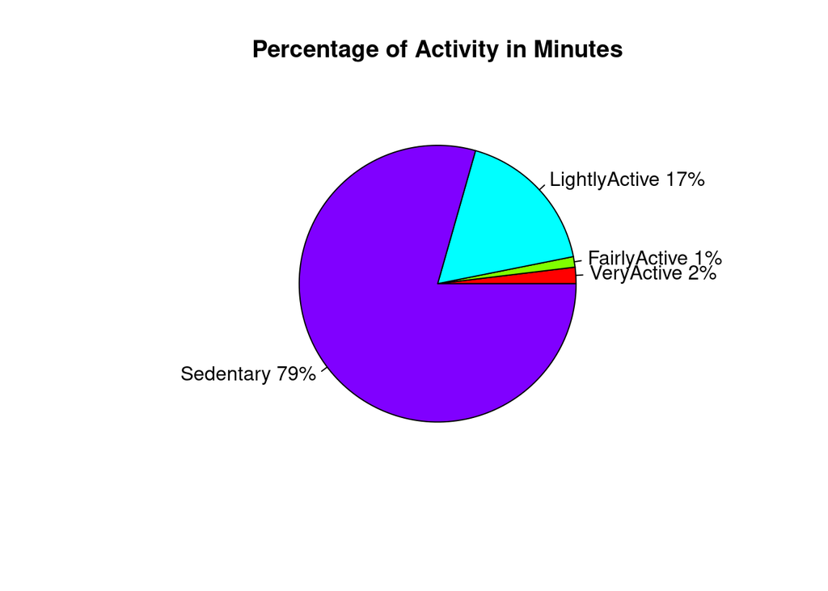

```r
VeryActiveMin <-sum(activity_daily_final$VeryActiveMinutes)
FairlyActiveMin <- sum(activity_daily_final$FairlyActiveMinutes)
LightlyActiveMin <- sum(activity_daily_final$LightlyActiveMinutes)
SedentaryMin <- sum(activity_daily_final$SedentaryMinutes)
TotalMin <- VeryActiveMin + FairlyActiveMin + LightlyActiveMin +SedentaryMin
slices <- c(VeryActiveMin, FairlyActiveMin, LightlyActiveMin,SedentaryMin)
lbls <- c("VeryActive", "FairlyActive", "LightlyActive", "Sedentary")
pct <- round(slices/sum(slices)*100)
lbls <- paste(lbls,pct)
lbls <-paste(lbls, "%", sep="")
pie(slices, labels = lbls, col = rainbow(length(lbls)), main= "Percentage of Activity in Minutes")
```

It is visually seen that the individuals are not active enough, as 79% of the activity time for an entire month was spent being sedentary for the average user. For a fitness tracking watch, this is not a good observation as people purchase fitness services in order to be mroe active.

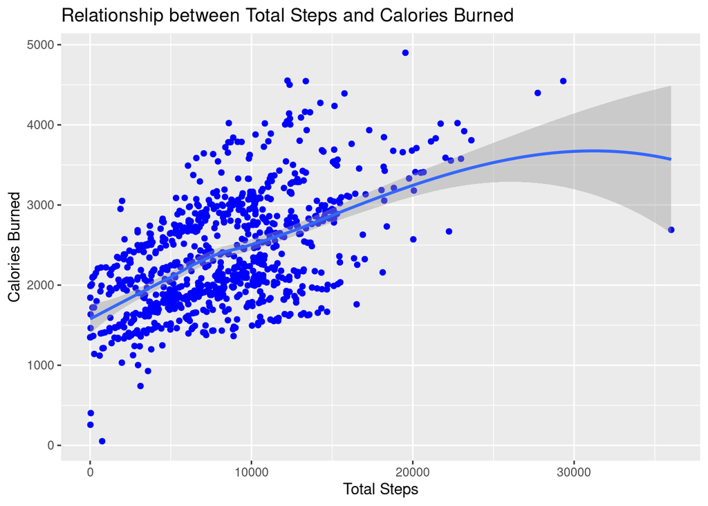

```r
ggplot(data=activity_daily_final) + geom_point(mapping =aes(x=TotalSteps, y= Calories), color = "blue") + geom_smooth(mapping = aes(x=TotalSteps, y= Calories)) + labs(title = "Relationship between Total Steps and Calories Burned", x="Total Steps", y = "Calories Burned")
```

Although this relationship should be obvious, the more steps an individual takes, the more calories are burned. And of course, the more active a person is, the more steps they will take, which then means more calories are burned. The average person from this data set is only reaching about 8000 Total Steps for the day, which equates to just under 2500 calories burned for the day.

Without more information regarding the person’s diet,age, sex, and height, it would be impossible to say exactly how many calories the person needs to burn to lose weight at a healthy rate.

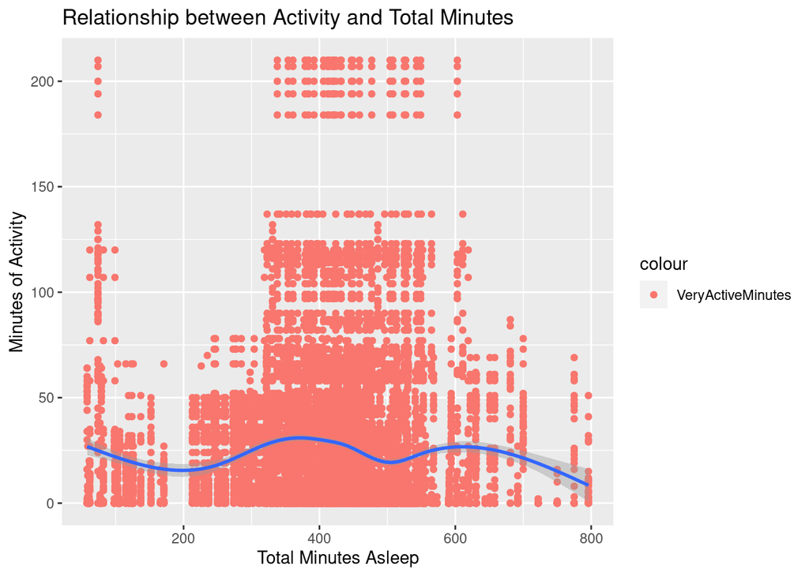

```r
combined_data <- merge(activity_daily_final,sleep_daily_final, by ="Id")
ggplot(data=combined_data) + geom_point(mapping=aes(x= TotalMinutesAsleep, y=VeryActiveMinutes, color = "VeryActiveMinutes")) + geom_smooth(mapping=aes(x= TotalMinutesAsleep, y=VeryActiveMinutes, regLineColor="blue")) + labs(title = "Relationship between Activity and Total Minutes", x = "Total Minutes Asleep", y= "Minutes of Activity")
```

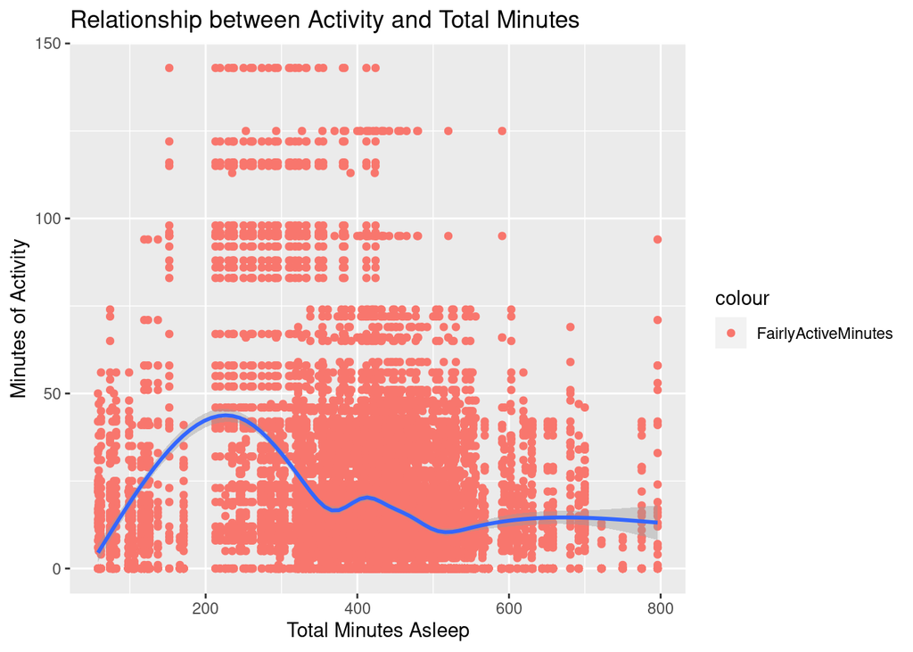

```r
ggplot(data=combined_data) + geom_point(mapping=aes(x= TotalMinutesAsleep, y=FairlyActiveMinutes, color = "FairlyActiveMinutes")) + geom_smooth(mapping=aes(x = TotalMinutesAsleep, y=FairlyActiveMinutes, regLineColor="blue")) + labs(title = "Relationship between Activity and Total Minutes", x = "Total Minutes Asleep", y= "Minutes of Activity")
```

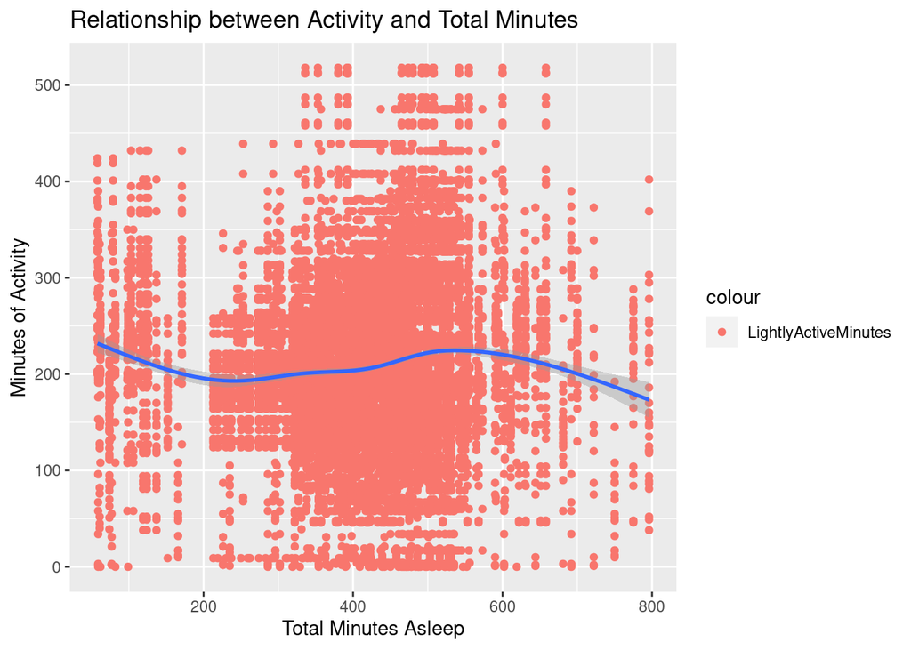

```r
ggplot(data=combined_data) + geom_point(mapping=aes(x=TotalMinutesAsleep, y=LightlyActiveMinutes, color = "LightlyActiveMinutes")) + geom_smooth(mapping=aes(x=TotalMinutesAsleep, y=LightlyActiveMinutes, regLineColor="blue")) +labs(title = "Relationship between Activity and Total Minutes", x = "Total Minutes Asleep", y= "Minutes of Activity")
```

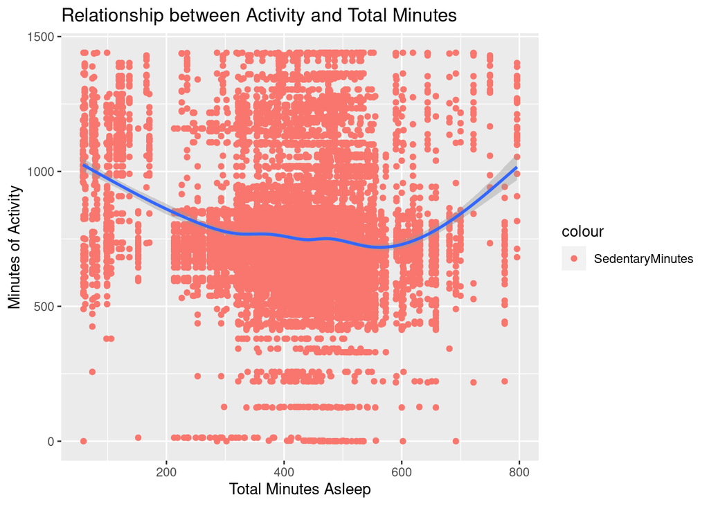

```r
ggplot(data=combined_data) + geom_point(mapping=aes(x=TotalMinutesAsleep, y=SedentaryMinutes, color = "SedentaryMinutes")) + geom_smooth(mapping=aes(x= TotalMinutesAsleep, y=SedentaryMinutes, regLineColor="blue")) + labs(title = "Relationship between Activity and Total Minutes", x = "Total Minutes Asleep", y= "Minutes of Activity")
```

These graphs show the relationship between total minutes asleep against each activity level. I needed to observe if there was a relationship between higher actiivity levels and sleep and another observation was if the watch logs sleep as sedentary. As you can see in the sedentary group, regardless of the quality of sleep, the average person was still sedentary.